# Model Creation for Forecasting CA, NY, LA, NYC

In order to model Gompertz, we need to install the following package.

```r
install.packages("easynls")
```

We start first with model creation for California COVID-19 cumulative cases.

California State Model Creation

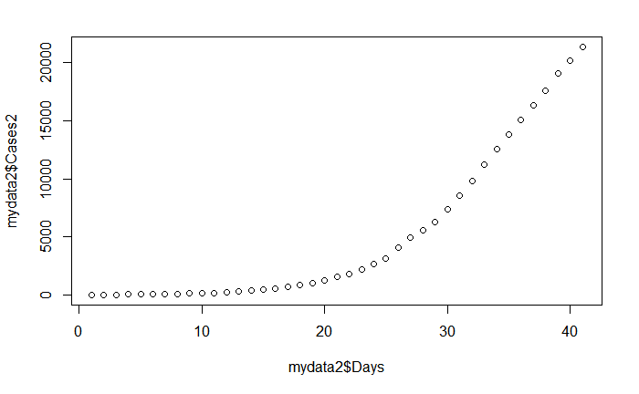

```r
cadata <- read.table("CaliforniaData.csv", header=TRUE,sep=",")
attach(cadata)
library(easynls)
Days = Time
Cases2 = cases
mydata1 =cbind(Days, Cases2)
mydata2 = as.data.frame(mydata1[1:41,])
plot(mydata2$Days,mydata2$Cases2)
```

Next, we ready to model. Note that model = 10 is the Gompertz model.

Parameter a: We estimated parameter using Italy as a benchmark. To do this, we create a ratio by taking the current number of cases and dividing by Italy’s population: 156,363 / 60,461,826 = .0025861442 Italy population found from Eurostat and https://www.worldometers.info/coronavirus/country/italy/. Note that this number has since changed.

We take the ratio of .0025861442 multiply California population of about 37 million, retrieved from Census. This gets us our parameter a.

```r
Model2 = nlsfit(mydata2, model = 10, start = c(a = 96170, b = 2, c = .1))
Model2
```

```
$Model
[1] "y~a*exp(-b*exp(-c*x)"

$Parameters
```

|  | Cases2 |
| --- | --- |
| coefficient a | 5.469086e+04 |
| coefficient b | 1.533547e+01 |
| coefficient c | 6.847127e-02 |
| p-value t.test for a | 0.000000e+00 |
| p-value t.test for b | 0.000000e+00 |
| p-value t.test for c | 0.000000e+00 |
| r-squared | 9.992000e-01 |
| adjusted r-squared | 9.992000e-01 |
| AIC | 5.508259e+02 |
| BIC | 5.576802e+02 |

```
NA
```

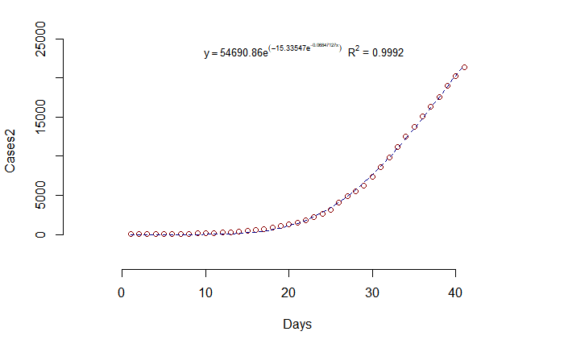

```r
nlsplot(mydata2, model = 10, start = c(a = 96170, b = 2, c = .1), xlab = "Days", ylab = "Cases2", position = 1)
```

Therefore, our California Model is as follows:

```
                                        (-.06847127*t)
                          (-15.33547*e^)
```

Cumulative Cases = 54690.86*e^

New York State Model Creation

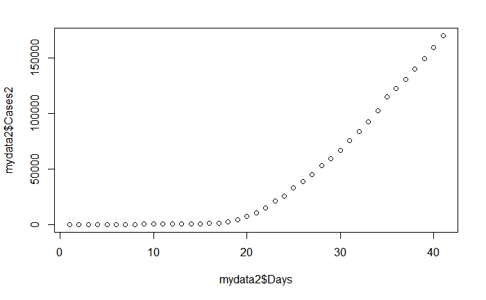

```r
nydata <- read.table("NYData.csv", header=TRUE,sep=",")
attach(nydata)
Days = Time
Cases2 = Cases
mydata1 = cbind(Days, Cases2)
mydata2 = as.data.frame(mydata1[1:41,])
plot(mydata2$Days,mydata2$Cases2)
```

```r
Model2 = nlsfit(mydata2, model = 10, start = c(a = 50115, b = 2, c = .1))
Model2
```

```
$Model
[1] "y~a*exp(-b*exp(-c*x)"

$Parameters
```

|  | Cases2 |
| --- | --- |
| coefficient a | 3.045319e+05 |
| coefficient b | 1.902339e+01 |
| coefficient c | 8.450772e-02 |
| p-value t.test for a | 0.000000e+00 |
| p-value t.test for b | 0.000000e+00 |
| p-value t.test for c | 0.000000e+00 |
| r-squared | 9.994000e-01 |
| adjusted r-squared | 9.994000e-01 |
| AIC | 7.101148e+02 |
| BIC | 7.169691e+02 |

```
NA
```

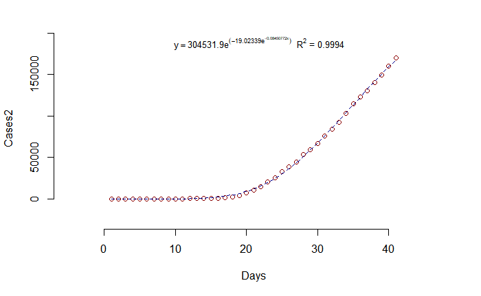

```r
nlsplot(mydata2, model = 10, start = c(a = 50115, b = 2, c = .1), xlab = "Days", ylab = "Cases2", position = 1)
```

Therefore, our New York Model is as follows:

```
                              (-.08450772*t)
              (-19.02339*e^)
```

y = 304531.9*e^

Los Angeles Model Creation

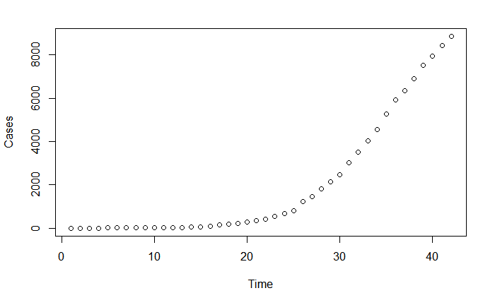

```r
LAdata <- read.table("LAdata.csv", header=TRUE,sep=",")
attach(LAdata)
plot(Time, Cases)
```

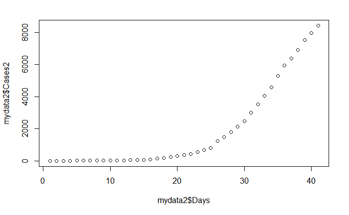

```r
library(easynls)
Days = Time
Cases2 = Cases
mydata1 =cbind(Days, Cases2)
mydata2 = as.data.frame(mydata1[1:41,])
plot(mydata2$Days,mydata2$Cases2)
```

```r
Model2 = nlsfit(mydata2, model = 10, start = c(a = 20639, b = 1, c = .1))
Model2
```

```
$Model
[1] "y~a*exp(-b*exp(-c*x)"

$Parameters
```

|  | Cases2 |
| --- | --- |
| coefficient a | 1.739430e+04 |
| coefficient b | 2.764857e+01 |
| coefficient c | 8.934937e-02 |
| p-value t.test for a | 0.000000e+00 |
| p-value t.test for b | 0.000000e+00 |
| p-value t.test for c | 0.000000e+00 |
| r-squared | 9.992000e-01 |
| adjusted r-squared | 9.992000e-01 |
| AIC | 4.747286e+02 |
| BIC | 4.815829e+02 |

```
NA
```

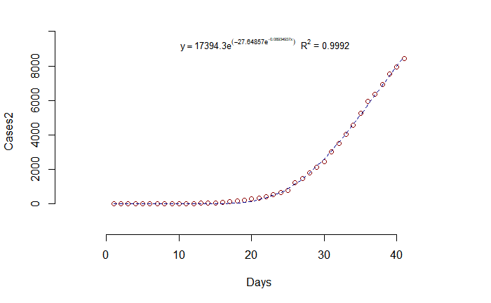

```r
nlsplot(mydata2, model = 10, start = c(a =  20639, b = 1, c = .1), xlab = "Days", ylab = "Cases2", position = 1)
```

Therefore, our Los Angeles Model is as follows:

```
                    (-.08934937*t)
        (-27.64857*e^)
```

y = 17394.3*e^

New York City Model Creation

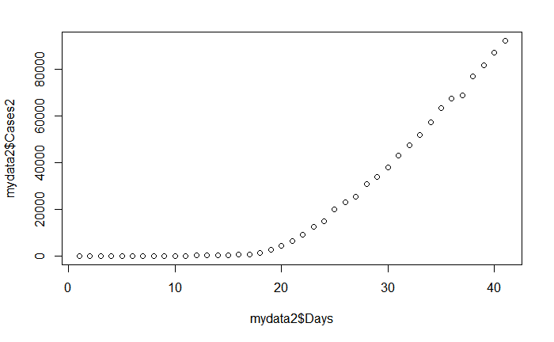

```r
NYCdata <- read.table("NYCityData.csv", header=TRUE,sep=",")
attach(NYCdata)
library(easynls)
Days = Time
Cases2 = cases
mydata1 =cbind(Days, Cases2)
mydata2 = as.data.frame(mydata1[1:41,])
plot(mydata2$Days,mydata2$Cases2)
```

```r
Model2 = nlsfit(mydata2, model = 10, start = c(a = 43442, b = 2, c = .1))
Model2
```

```
$Model
[1] "y~a*exp(-b*exp(-c*x)"

$Parameters
```

|  | Cases2 |
| --- | --- |
| coefficient a | 1.561178e+05 |
| coefficient b | 1.881375e+01 |
| coefficient c | 8.642902e-02 |
| p-value t.test for a | 0.000000e+00 |
| p-value t.test for b | 0.000000e+00 |
| p-value t.test for c | 0.000000e+00 |
| r-squared | 9.989000e-01 |
| adjusted r-squared | 9.988000e-01 |
| AIC | 6.894874e+02 |
| BIC | 6.963417e+02 |

```
NA
```

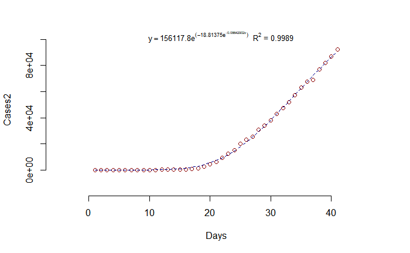

```r
nlsplot(mydata2, model = 10, start = c(a = 43442, b = 2, c = .1), xlab = "Days", ylab = "Cases2", position = 1)
```

Therefore, our model for New York City is as follows:

[output not shown]

y = 156117.8*e^